# Group Homework

Tigran Sedrakyan

July 21, 2018

# Quantitative Analysis

## Getting the data

For getting the quantitative data, we chose API requests to [Exchange Rates API](https://exchangeratesapi.io/). This API provides exchange rates of currencies for any day since 1999. We made several types of date requests, but for any of them the base currency was chosen the USD.

## Analysing the data

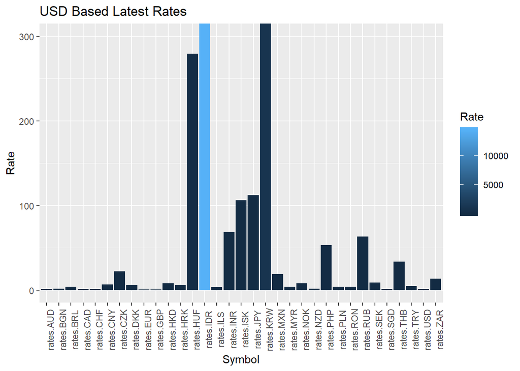

In the bar plot above we can see the latest exchange rates based on US dollar. The x-axis shows the symbols for currencies and the rates are depicted on the y-axis. According do the plot, we can say that after IDR and KRW, HUF and JPY have the highest rates. Moreover, GBP has the lowest rate. We can represent the same chart in a bit more elegant form.

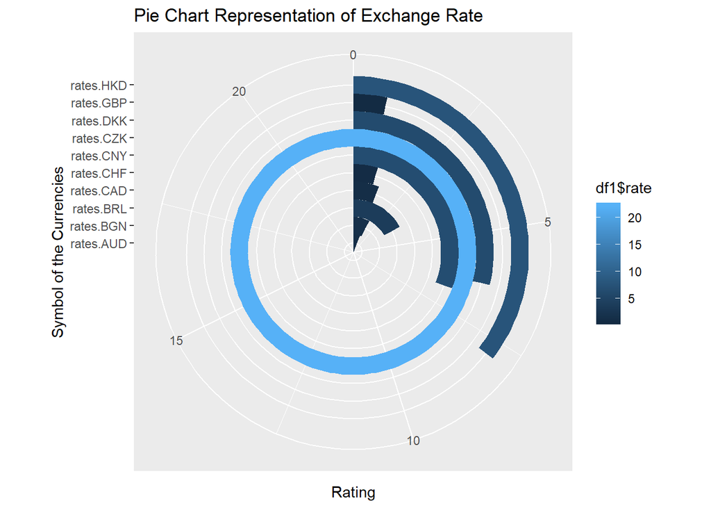

However those chart stand for the most recent exchange rates. Let’s see, however, how the rate for EUR has changed, for the last 4 years.

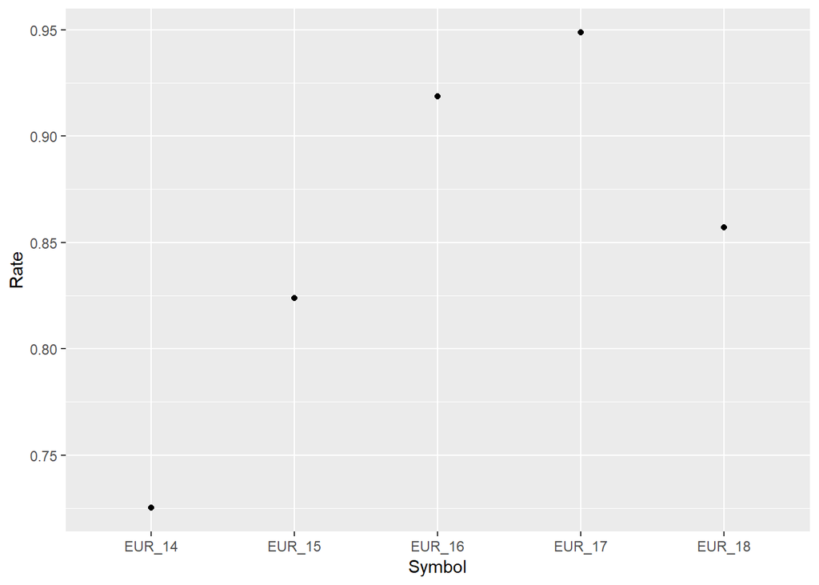

This plot shows a general idea about the rates of EURO based USD from 2014 to 2018. For the plot, only a single day has been chosen each year for a genral idea about the behavior of the rates thorugh years. We enounter the hight rate in 2017 and the lowest 2014. We see a constant increase with the exception of last year, when rate for Euro has dropped.